# Demystifying the Nutrition Facts

Manufacturers measure cereal nutrition by serving. However, most people in real life measure cereal by volume, for example, a cup. This makes nutrition facts are hard to understand, and ever are misleading.

```r
library(RCurl)
library(ggplot2)
```

**mfr: Manufacturer of cereal**

A = American Home Food Products

G = General Mills

K = Kelloggs

N = Nabisco

P = Post

Q = Quaker Oats

R = Ralston Purina

**type:**

cold

hot

```r
url <- getURL('https://raw.githubusercontent.com/frankwwu/R-Knots/master/80%20Cereals/cereal.csv')
cereals <- read.csv(text = url)
```

Display the columns and data types.

```r
strings <- cereals[1, ]
head(strings)
```

|  | name | mfr | type | calories | protein | fat | sodium | fiber | carbo | sugars | potass | vitamins | shelf | weight | cups | rating |
| --- | --- | --- | --- | --- | --- | --- | --- | --- | --- | --- | --- | --- | --- | --- | --- | --- |
| 1 | String | Categorical | Categorical | Int | Int | Int | Int | Float | Float | Int | Int | Int | Int | Float | Float | Float |

```r
cereals = cereals[-1,]
head(cereals)
```

|  | name | mfr | type | calories | protein | fat | sodium | fiber | carbo | sugars | potass | vitamins | shelf | weight | cups | rating |
| --- | --- | --- | --- | --- | --- | --- | --- | --- | --- | --- | --- | --- | --- | --- | --- | --- |
| 2 | 100% Bran | N | C | 70 | 4 | 1 | 130 | 10 | 5 | 6 | 280 | 25 | 3 | 1 | 0.33 | 68.402973 |
| 3 | 100% Natural Bran | Q | C | 120 | 3 | 5 | 15 | 2 | 8 | 8 | 135 | 0 | 3 | 1 | 1 | 33.983679 |
| 4 | All-Bran | K | C | 70 | 4 | 1 | 260 | 9 | 7 | 5 | 320 | 25 | 3 | 1 | 0.33 | 59.425505 |
| 5 | All-Bran with Extra Fiber | K | C | 50 | 4 | 0 | 140 | 14 | 8 | 0 | 330 | 25 | 3 | 1 | 0.5 | 93.704912 |
| 6 | Almond Delight | R | C | 110 | 2 | 2 | 200 | 1 | 14 | 8 | -1 | 25 | 3 | 1 | 0.75 | 34.384843 |
| 7 | Apple Cinnamon Cheerios | G | C | 110 | 2 | 2 | 180 | 1.5 | 10.5 | 10 | 70 | 25 | 1 | 1 | 0.75 | 29.509541 |

How do manufacturers measure nutrition facts?

```r
mfr <- unique(cereals$mfr)
print(paste(length(mfr), 'manufacturers'))
```

```
[1] "7 manufacturers"
```

```r
print(mfr)
```

```
[1] N Q K R G P A
Levels: A Categorical G K N P Q R
```

```r
weight <- unique(cereals$weight)
print(paste(length(weight), 'weight'))
```

```
[1] "7 weight"
```

```r
print(weight)
```

```
[1] 1.00 1.33 1.25 1.30 1.50 0.50 0.83
```

```r
cups <- unique(cereals$cups)
print(paste(length(cups), 'cups'))
```

```
[1] "12 cups"
```

```r
print(cups)
```

```
 [1] 0.33 1.00 0.50 0.75 0.67 1.25 0.80 0.88 0.25 1.33 1.50 1.13
```

Manufacturers like to measure nutrition with serving. Every manufacturer chaotically defines the serving with different weights and cups. Thus, for consumers, comparing nutrition measured with different serving is practically very confusing. Imagine you are comparing nutrition facts of different cereals in a grocery store and they are measured with different serving, you definitely need a calculator and a piece of paper.

```r
cereals$calories <- as.integer(as.character(cereals$calories))
cereals$protein <- as.integer(as.character(cereals$protein))
cereals$fat <- as.integer(as.character(cereals$fat))
cereals$sodium <- as.integer(as.character(cereals$sodium))
cereals$fiber <- as.numeric(as.character(cereals$fiber))
cereals$carbo <- as.numeric(as.character(cereals$carbo))
cereals$sugars <- as.integer(as.character(cereals$sugars))
cereals$potass <- as.integer(as.character(cereals$potass))
cereals$vitamins <- as.integer(as.character(cereals$vitamins))
cereals$shelf <- as.integer(as.character(cereals$shelf))
cereals$weight <- as.numeric(as.character(cereals$weight))
cereals$cups <- as.numeric(as.character(cereals$cups))
cereals$rating <- as.numeric(as.character(cereals$rating))
```

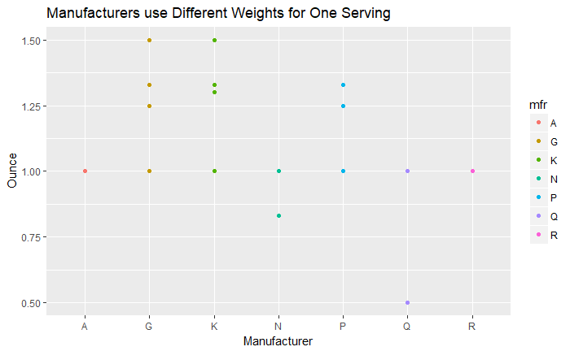

```r
ggplot() +
  geom_point(cereals, mapping=aes(x=mfr, y=weight, color=mfr)) +
  labs(x="Manufacturer", y="Ounce") +
  ggtitle("Manufacturers use Different Weights for One Serving")
```

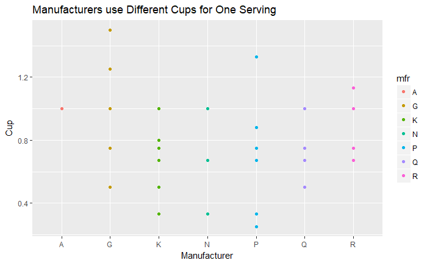

```r
ggplot() +
  geom_point(cereals, mapping=aes(x=mfr, y=cups, color=mfr)) +
  labs(x="Manufacturer", y="Cup") +
  ggtitle("Manufacturers use Different Cups for One Serving")
```

Let’s prepare the data to compare some nutrition per serving and per cup.

Convert nutrition to per cup.

```r
# Normalize with cup
cereals.cup <- data.frame(
  mfr = cereals$mfr,
  type = cereals$type,
  calories= round(as.numeric(cereals$calories) / as.numeric(cereals$cups)),
  protein= round(as.numeric(cereals$protein) / as.numeric(cereals$cups)),
  fat= round(as.numeric(cereals$fat) / as.numeric(cereals$cups)),
  sodium = round(as.numeric(cereals$sodium) / as.numeric(cereals$cups)),
  fiber = round(as.numeric(cereals$fiber) / as.numeric(cereals$cups)),
  carbo = round(as.numeric(cereals$carbo) / as.numeric(cereals$cups)),
  sugars = round(as.numeric(cereals$sugars) / as.numeric(cereals$cups)),
  potass = round(as.numeric(cereals$potass) / as.numeric(cereals$cups)),
  vitamins = round(as.numeric(cereals$vitamins) / as.numeric(cereals$cups)),
  shelf = round(as.numeric(cereals$shelf) / as.numeric(cereals$cups)),
  weight = as.numeric(cereals$weight) / as.numeric(cereals$cups),
  rating = cereals$rating)
```

Comparing nutrition per serving and per cup.

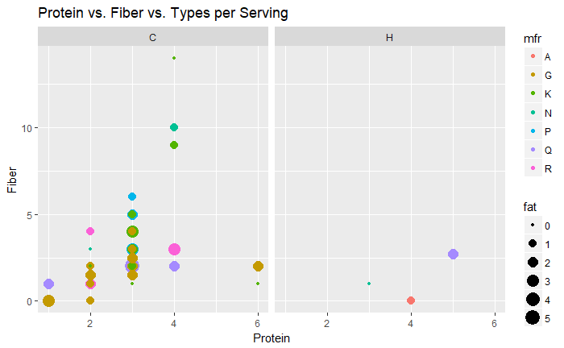

```r
plot_protein_fiber <- function(cereals, title){
  ggplot() +
    geom_point(cereals, mapping=aes(x=protein, y=fiber, color=mfr, size=fat)) +
    facet_grid(. ~ type) +
    labs(x="Protein", y="Fiber") +
    ggtitle(title)
}
plot_protein_fiber(cereals, "Protein vs. Fiber vs. Types per Serving")
```

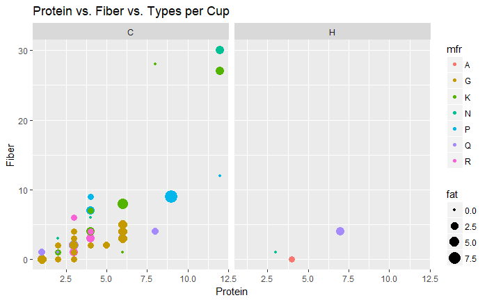

```r
plot_protein_fiber(cereals.cup, "Protein vs. Fiber vs. Types per Cup")
```

Calories per serving and per cup are obversely different.

```r
cat("Range of calories per weight:", min(cereals$calories, na.rm = TRUE), "-", max(cereals$calories, na.rm = TRUE), "\n")
```

```
Range of calories per weight: 50 - 160
```

```r
cat("Range of calories per cup:", min(cereals.cup$calories, na.rm = TRUE), "-", max(cereals.cup$calories, na.rm = TRUE), "\n")
```

```
Range of calories per cup: 50 - 440
```

Sugar and calories per serving and per cup are very different.

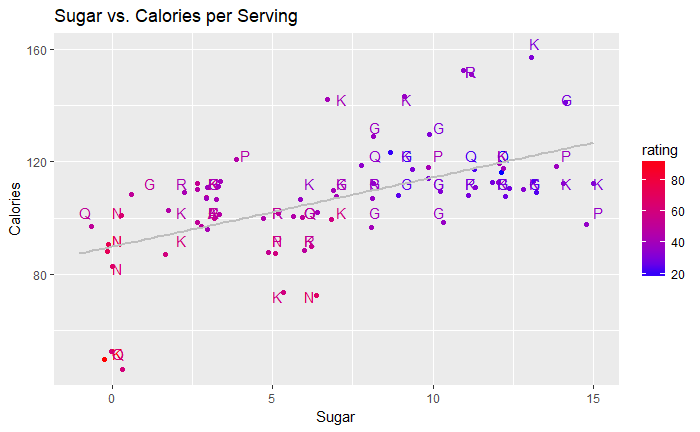

```r
plot_sugars_calories <- function(cereals, title){
  ggplot(data=cereals, aes(x=sugars, y=calories, col=rating)) +
    geom_jitter() +
    geom_text(aes(label=mfr),hjust=0, vjust=0) +
    labs(x="Sugar", y="Calories") +
    geom_smooth(method="lm", se=FALSE, col="grey") +
    scale_color_gradient(low="blue", high="red") +
    ggtitle(title)
}
plot_sugars_calories(cereals, "Sugar vs. Calories per Serving")
```

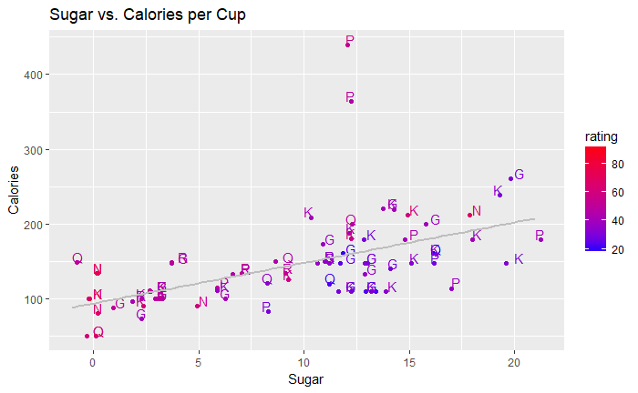

```r
plot_sugars_calories(cereals.cup, "Sugar vs. Calories per Cup")
```

Sugar and sodium per serving and per cup are also different.

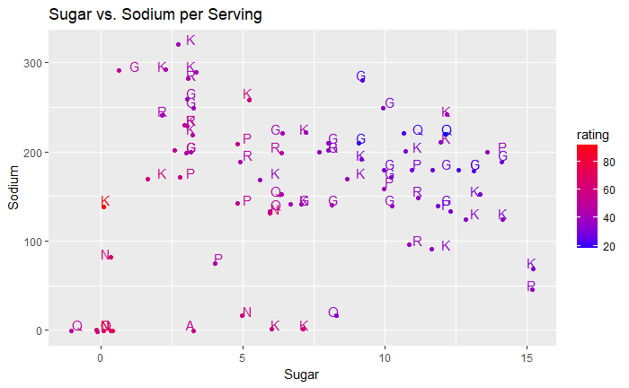

```r
plot_sugars_sodium <- function(cereals, title){
  ggplot(data=cereals, aes(x=sugars, y=sodium, col=rating)) +
    geom_jitter() +
    geom_text(aes(label=mfr),hjust=0, vjust=0) +
    labs(x="Sugar", y="Sodium") +
    scale_color_gradient(low="blue", high="red") +
    ggtitle(title)
}
plot_sugars_sodium(cereals, "Sugar vs. Sodium per Serving")
```

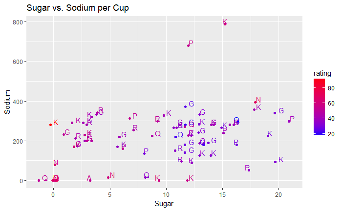

```r
plot_sugars_sodium(cereals.cup, "Sugar vs. Sodium per Cup")
```

For simplicity, let’s combine good and bad nutrition, and examine the difference.

```r
cereals.per.serving <- data.frame(
  mfr = cereals$mfr,
  good = cereals$protein + cereals$fiber + cereals$vitamins,
  bad = cereals$fat + cereals$sodium + cereals$potass + cereals$sugars,
  rating = cereals$rating
)
cereals.per.cup <- data.frame(
  mfr = cereals.cup$mfr,
  good = cereals.cup$protein + cereals.cup$fiber + cereals.cup$vitamins,
  bad = cereals.cup$fat + cereals.cup$sodium + cereals.cup$potass + cereals.cup$sugars,
  rating = cereals$rating
)
```

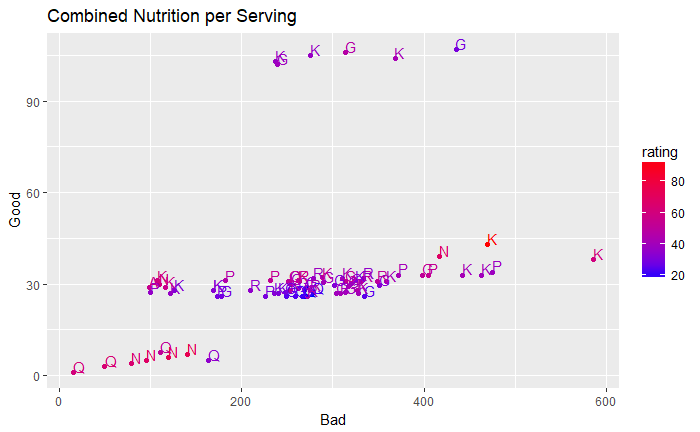

```r
plot_combined <- function(cereals, title){
  ggplot(data=cereals, aes(x=bad, y=good, col=rating)) +
    geom_jitter() +
    geom_text(aes(label=mfr),hjust=0, vjust=0) +
    labs(x="Bad", y="Good") +
    scale_color_gradient(low="blue", high="red") +
    ggtitle(title)
}
plot_combined(cereals.per.serving, "Combined Nutrition per Serving")
```

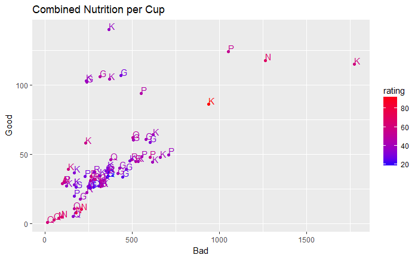

```r
plot_combined(cereals.per.cup, "Combined Nutrition per Cup")
```

Conclution: It is almost impossible to quickly compare nutrition facts when you are shopping in a grocery store.